# Tugas-mpdw3

Fadly Mochammad Taufiq

# 1 Pra Analisis

## 1.1 aktifkan package

```r
library(dLagM)
library(dynlm)
library(MLmetrics)
library(lmtest)
library(car)
library(rio)
```

## 1.2 Input Data

```r
Data <- import("https://raw.githubusercontent.com/imomenujung/MPDW/main/Pertemuan%203/RepsolStockData20Years.csv")
Data <- Data[1:500, ]
```

## 1.3 mempersiapkan data

```r
## mengambil peubah open dan volume
Data <- subset(Data, select = c(open, volume))

## mengubah nama colom open menjadi Yt dan volume menjadi Xt
library(dplyr)
Data <- Data %>%
  rename(Xt = volume, Yt = open)

## Split data
train<-Data[1:400,]
test<-Data[401:500,]

## data time series
train.ts<-ts(train)
test.ts<-ts(test)
Data.ts<-ts(Data)
Data.ts
```

```
## Time Series:
## Start = 1
## End = 500
## Frequency = 1
##        Yt       Xt
##   1 11.12  4864322
##   2 10.76  5520210
##   3 10.92  7038886
##   4 11.42  7282602
##   5 11.44  7075356
##   6 11.45  5626819
##   7 11.32  5579050
##   8 11.02  9052957
##   9 11.11  4987451
##  10 11.36  5274492
```

[output cut: 490 more lines]

# 2 Pemodelan

## 2.1 model koyck

```r
## pemodelan
model.koyck <- koyckDlm(x = train$Xt, y = train$Yt)
summary(model.koyck)
```

```
##
## Call:
## "Y ~ (Intercept) + Y.1 + X.t"
##
## Residuals:
##       Min        1Q    Median        3Q       Max
## -0.740976 -0.094940  0.004319  0.109893  0.571444
##
## Coefficients:
##              Estimate Std. Error t value Pr(>|t|)
## (Intercept) 1.372e-01  8.935e-02   1.536    0.125
## Y.1         9.899e-01  6.020e-03 164.441   <2e-16 ***
## X.t         2.359e-09  2.398e-09   0.984    0.326
## ---
## Signif. codes:  0 '***' 0.001 '**' 0.01 '*' 0.05 '.' 0.1 ' ' 1
##
## Residual standard error: 0.1973 on 396 degrees of freedom
## Multiple R-Squared: 0.9858,  Adjusted R-squared: 0.9857
## Wald test: 1.374e+04 on 2 and 396 DF,  p-value: < 2.2e-16
##
## Diagnostic tests:
## NULL
##
##                             alpha         beta       phi
## Geometric coefficients:  13.52379 2.358975e-09 0.9898546
```

```r
AIC(model.koyck)
```

```
## [1] -157.7084
```

```r
BIC(model.koyck)
```

```
## [1] -141.7526
```

Dari hasil tersebut, didapat bahwa peubah $y_{t-1}$ memiliki nilai $P-Value<0.05$. Hal ini menunjukkan bahwa peubah $y_{t-1}$ berpengaruh signifikan terhadap $y$. Adapun model keseluruhannya adalah sebagai berikut

$$\hat{Y_t}=(1.372e-01)+(2.359e-09)X_t+(9.899e-01)Y_{t-1}$$

Berikut adalah hasil peramalan y untuk 100 periode kedepan menggunakan model koyck

```r
fore.koyck <- forecast(model = model.koyck, x=test$Xt, h=100)
fore.koyck
```

```
## $forecasts
##   [1] 17.26715 17.24773 17.22905 17.24000 17.21649 17.20890 17.20159 17.18550
##   [9] 17.20219 17.21310 17.20770 17.22208 17.25259 17.30208 17.30539 17.37978
##  [17] 17.39709 17.37969 17.35267 17.33116 17.35470 17.33770 17.34314 17.31995
##  [25] 17.29264 17.26370 17.24639 17.22788 17.23332 17.21030 17.18610 17.16853
##  [33] 17.14806 17.12526 17.12309 17.10171 17.07961 17.09663 17.08241 17.07491
##  [41] 17.06045 17.05586 17.04436 17.03462 17.08709 17.06912 17.05551 17.03972
##  [49] 17.02198 17.00445 16.97975 16.96237 16.94188 16.91882 16.90835 16.88744
##  [57] 16.87400 16.88586 16.87061 16.88805 16.87816 16.87945 16.89405 16.89944
##  [65] 16.87543 16.85812 16.84218 16.81820 16.80731 16.80169 16.78231 16.76344
##  [73] 16.76532 16.78651 16.78385 16.77111 16.75577 16.74486 16.72299 16.74510
##  [81] 16.73138 16.71839 16.70950 16.70000 16.68583 16.67383 16.66585 16.65670
##  [89] 16.63265 16.63658 16.61785 16.59868 16.57411 16.55797 16.54423 16.52677
##  [97] 16.50392 16.49188 16.47341 16.47908
##
## $call
## forecast.koyckDlm(model = model.koyck, x = test$Xt, h = 100)
##
## attr(,"class")
## [1] "forecast.koyckDlm" "dLagM"
```

```r
mape.koyck <- MAPE(fore.koyck$forecasts, test$Yt)
## akurasi data training
GoF(model.koyck)
```

```
##               n       MAE           MPE       MAPE      sMAPE    MASE
## model.koyck 399 0.1464091 -0.0001842306 0.01032404 0.01031549 1.00571
##                    MSE    MRAE    GMRAE
## model.koyck 0.03865086 9357859 1.988653
```

## 2.2 Regression with Distributed Lag

Pemodelan (Lag=2)

```r
model.dlm <- dlm(x = train$Xt,y = train$Yt , q = 2)
summary(model.dlm)
```

```
##
## Call:
## lm(formula = model.formula, data = design)
##
## Residuals:
##     Min      1Q  Median      3Q     Max
## -3.6217 -1.2581 -0.1719  1.1267  3.6194
##
## Coefficients:
##              Estimate Std. Error t value Pr(>|t|)
## (Intercept) 1.445e+01  1.511e-01  95.611   <2e-16 ***
## x.t         5.205e-09  9.438e-09   0.551    0.582
## x.1         6.365e-09  1.018e-08   0.625    0.532
## x.2         5.066e-09  9.439e-09   0.537    0.592
## ---
## Signif. codes:  0 '***' 0.001 '**' 0.01 '*' 0.05 '.' 0.1 ' ' 1
##
## Residual standard error: 1.644 on 394 degrees of freedom
## Multiple R-squared:  0.005607,   Adjusted R-squared:  -0.001965
## F-statistic: 0.7405 on 3 and 394 DF,  p-value: 0.5284
##
## AIC and BIC values for the model:
##        AIC      BIC
## 1 1531.001 1550.933
```

```r
AIC(model.dlm)
```

```
## [1] 1531.001
```

```r
BIC(model.dlm)
```

```
## [1] 1550.933
```

```r
fore.dlm <- forecast(model = model.dlm, x=test$Xt, h=100)
fore.dlm
```

```
## $forecasts
##   [1] 14.62616 14.59186 14.59175 14.64377 14.64859 14.65374 14.62276 14.63744
##   [9] 14.68593 14.74253 14.76170 14.74948 14.80383 14.93265 14.91887 14.99395
##  [17] 14.96345 14.88799 14.65226 14.56321 14.65522 14.69851 14.73518 14.64565
##  [25] 14.60678 14.52945 14.53995 14.56341 14.63648 14.63498 14.60624 14.55552
##  [33] 14.56292 14.56271 14.59426 14.60141 14.59128 14.63326 14.66766 14.68184
##  [41] 14.61735 14.63395 14.62974 14.63548 14.76199 14.77887 14.73284 14.58888
##  [49] 14.58694 14.57634 14.55567 14.55151 14.54755 14.54774 14.56044 14.56457
##  [57] 14.57865 14.63111 14.65505 14.70804 14.67795 14.69900 14.69999 14.73972
##  [65] 14.67913 14.59476 14.55179 14.55078 14.55955 14.58799 14.59903 14.57351
##  [73] 14.59005 14.68883 14.73300 14.68844 14.60438 14.58473 14.56598 14.64184
##  [81] 14.65757 14.65675 14.59066 14.60109 14.59723 14.58734 14.59116 14.60324
##  [89] 14.57517 14.59323 14.58598 14.58310 14.52048 14.52209 14.53709 14.55217
##  [97] 14.53427 14.53429 14.53644 14.59431
##
## $call
## forecast.dlm(model = model.dlm, x = test$Xt, h = 100)
##
## attr(,"class")
## [1] "forecast.dlm" "dLagM"
```

```r
mape.dlm <- MAPE(fore.dlm$forecast, test$Yt)
## akurasi data training
GoF(model.dlm)
```

```
##             n      MAE         MPE       MAPE     sMAPE     MASE      MSE
## model.dlm 398 1.345747 -0.01246847 0.09263183 0.0918196 9.246482 2.674422
##                MRAE    GMRAE
## model.dlm 641097033 19.94346
```

penentuan lag optimum

```r
finiteDLMauto(formula = Yt ~ Xt,
              data = data.frame(train), q.min = 1, q.max = 6,
              model.type = "dlm", error.type = "AIC", trace = FALSE)
```

```
##   q - k    MASE      AIC      BIC    GMRAE   MBRAE R.Adj.Sq Ljung-Box
## 6     6 9.13758 1509.611 1545.398 19.99026 0.97455  -0.0093         0
```

Berdasarkan output tersebut, lag optimum didapatkan ketika lag=6. Selanjutnya dilakukan pemodelan untuk lag=6

model dlm dengan lag optimum

```r
model.dlm2 <- dlm(x = train$Xt,y = train$Yt , q = 6)
summary(model.dlm2)
```

```
##
## Call:
## lm(formula = model.formula, data = design)
##
## Residuals:
##     Min      1Q  Median      3Q     Max
## -3.5376 -1.2514 -0.1435  1.0669  3.5703
##
## Coefficients:
##               Estimate Std. Error t value Pr(>|t|)
## (Intercept)  1.441e+01  1.699e-01  84.851   <2e-16 ***
## x.t          2.091e-09  9.811e-09   0.213    0.831
## x.1          2.909e-09  1.035e-08   0.281    0.779
## x.2         -6.339e-11  1.025e-08  -0.006    0.995
## x.3          2.378e-09  1.007e-08   0.236    0.813
## x.4          2.379e-09  1.025e-08   0.232    0.817
## x.5          2.899e-09  1.036e-08   0.280    0.780
## x.6          9.757e-09  9.821e-09   0.993    0.321
## ---
## Signif. codes:  0 '***' 0.001 '**' 0.01 '*' 0.05 '.' 0.1 ' ' 1
##
## Residual standard error: 1.623 on 386 degrees of freedom
## Multiple R-squared:  0.008679,   Adjusted R-squared:  -0.009299
## F-statistic: 0.4828 on 7 and 386 DF,  p-value: 0.8471
##
## AIC and BIC values for the model:
##        AIC      BIC
## 1 1509.611 1545.398
```

```r
AIC(model.dlm2)
```

```
## [1] 1509.611
```

```r
BIC(model.dlm2)
```

```
## [1] 1545.398
```

$$\hat{Y_t}= (1.441e+01)+(2.091e-09)X_t+...+(9.757e-09)X_{t-6}$$
peramalan dan akurasi

```r
## peramalan
fore.dlm2 <- forecast(model = model.dlm2, x=test$Xt, h=100)
mape.dlm2 <- MAPE(fore.dlm2$forecast, test$Yt)
## akurasi data training
GoF(model.dlm2)
```

```
##              n      MAE         MPE       MAPE      sMAPE     MASE      MSE
## model.dlm2 394 1.328088 -0.01190051 0.09097118 0.09031426 9.137582 2.580382
##                 MRAE    GMRAE
## model.dlm2 646173604 19.99026
```

## 2.3 Model autoregressive

```r
## penentuan lag optimum
model.ardl.opt <- ardlBoundOrders(data = data.frame(Data), ic = "AIC",
                                  formula = Yt ~ Xt )
min_p=c()
for(i in 1:15){
  min_p[i]=min(model.ardl.opt$Stat.table[[i]])
}
q_opt=which(min_p==min(min_p, na.rm = TRUE))
p_opt=which(model.ardl.opt$Stat.table[[q_opt]] ==
              min(model.ardl.opt$Stat.table[[q_opt]], na.rm = TRUE))
data.frame("q_optimum" = q_opt, "p_optimum" = p_opt,
           "AIC"=model.ardl.opt$min.Stat)
```

```
##   q_optimum p_optimum       AIC
## 1        14         1 -285.4785
```

Selanjutnya dapat dilakukan pemodelan dengan nilai $p$ dan $q$ optimum seperti inisialisasi di langkah sebelumnya.

Pemodelan

```r
model.ardl <- ardlDlm(x = train$Xt, y = train$Yt, p = 1 , q = 14)
summary(model.ardl)
```

```
##
## Time series regression with "ts" data:
## Start = 15, End = 400
##
## Call:
## dynlm(formula = as.formula(model.text), data = data, start = 1)
##
## Residuals:
##      Min       1Q   Median       3Q      Max
## -0.64300 -0.10267  0.00676  0.10249  0.53710
##
## Coefficients:
##               Estimate Std. Error t value Pr(>|t|)
## (Intercept)  1.212e-01  9.114e-02   1.330 0.184239
## X.t          7.134e-10  1.107e-09   0.644 0.519657
## X.1          6.390e-10  1.109e-09   0.576 0.564642
## Y.1          9.574e-01  5.162e-02  18.547  < 2e-16 ***
## Y.2         -4.141e-02  7.168e-02  -0.578 0.563874
## Y.3          1.181e-01  7.178e-02   1.646 0.100620
## Y.4         -3.423e-02  7.119e-02  -0.481 0.630941
## Y.5         -7.559e-02  7.109e-02  -1.063 0.288372
## Y.6          3.229e-02  7.012e-02   0.461 0.645416
## Y.7          9.534e-02  7.035e-02   1.355 0.176161
## Y.8          4.425e-02  7.003e-02   0.632 0.527805
## Y.9         -2.533e-01  6.960e-02  -3.640 0.000312 ***
## Y.10         2.786e-02  7.100e-02   0.392 0.694961
## Y.11         1.494e-01  7.138e-02   2.093 0.037024 *
## Y.12         3.376e-02  7.168e-02   0.471 0.637910
## Y.13         4.828e-02  7.089e-02   0.681 0.496226
## Y.14        -1.104e-01  5.045e-02  -2.188 0.029315 *
## ---
## Signif. codes:  0 '***' 0.001 '**' 0.01 '*' 0.05 '.' 0.1 ' ' 1
##
## Residual standard error: 0.1873 on 369 degrees of freedom
## Multiple R-squared:  0.9863, Adjusted R-squared:  0.9857
## F-statistic:  1659 on 16 and 369 DF,  p-value: < 2.2e-16
```

```r
AIC(model.ardl)
```

```
## [1] -179.0472
```

```r
BIC(model.ardl)
```

```
## [1] -107.8421
```

```r
model.ardl <- ardlDlm(formula = Yt ~ Xt, data = train)
fore.ardl <- forecast(model = model.ardl, x=test$Xt, h=100)
fore.ardl
```

```
## $forecasts
##   [1] 17.26586 17.25265 17.23757 17.23028 17.22374 17.21029 17.20202 17.19165
##   [9] 17.18684 17.19104 17.18930 17.18743 17.19598 17.21453 17.22746 17.24373
##  [17] 17.26823 17.26578 17.24986 17.23230 17.22796 17.22772 17.22029 17.21279
##  [25] 17.19515 17.17581 17.15893 17.14548 17.13775 17.13047 17.11385 17.09856
##  [33] 17.08467 17.06930 17.05845 17.04932 17.03392 17.02824 17.02713 17.01779
##  [41] 17.00886 17.00025 16.99305 16.98413 16.99156 17.00099 16.98911 16.97808
##  [49] 16.96589 16.95316 16.93870 16.92384 16.91054 16.89562 16.88310 16.87196
##  [57] 16.85941 16.85568 16.85317 16.85032 16.85099 16.84581 16.84759 16.85130
##  [65] 16.84464 16.83033 16.81853 16.80514 16.79253 16.78545 16.77658 16.76347
##  [73] 16.75580 16.75967 16.76366 16.75751 16.74752 16.73783 16.72680 16.72345
##  [81] 16.72504 16.71542 16.70709 16.69993 16.69141 16.68197 16.67426 16.66755
##  [89] 16.65670 16.64822 16.64292 16.63030 16.61620 16.60252 16.59215 16.58162
##  [97] 16.56855 16.55652 16.54632 16.54020
##
## $call
## forecast.ardlDlm(model = model.ardl, x = test$Xt, h = 100)
##
## attr(,"class")
## [1] "forecast.ardlDlm" "dLagM"
```

```r
mape.ardl <- MAPE(fore.ardl$forecast, test$Yt)
mape.ardl
```

```
## [1] 0.03497467
```

```r
## akurasi data training
GoF(model.ardl)
```

```
##              n       MAE           MPE       MAPE      sMAPE     MASE
## model.ardl 399 0.1464895 -0.0001855758 0.01033622 0.01032946 1.006262
##                   MSE    MRAE    GMRAE
## model.ardl 0.03841473 8894028 1.992337
```

# 3 Perbandingan model

```r
akurasi <- matrix(c(mape.koyck, mape.dlm, mape.dlm2, mape.ardl))
row.names(akurasi)<- c("Koyck","DLM 1","DLM 2","Autoregressive")
colnames(akurasi) <- c("MAPE")
akurasi
```

```
##                      MAPE
## Koyck          0.03391040
## DLM 1          0.16227590
## DLM 2          0.16020072
## Autoregressive 0.03497467
```

Berdasarkan nilai MAPE, model paling optimum didapat pada Model Koyck karena memiliki nilai MAPE yang terkecil. Model Autoregressive berada dipilihan ke dua dan memiliki nilai MAPE yang berbeda tipis dengan koyck

# 4 plot

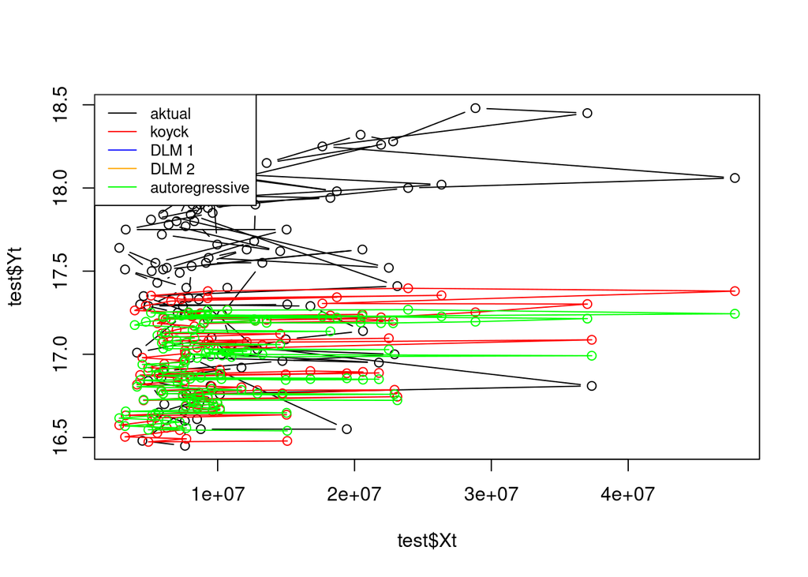

```r
par(mfrow=c(1,1))
plot(test$Xt, test$Yt, type="b", col="black")
points(test$Xt, fore.koyck$forecasts,col="red")
lines(test$Xt, fore.koyck$forecasts,col="red")
points(test$Xt, fore.dlm$forecasts,col="blue")
lines(test$Xt, fore.dlm$forecasts,col="blue")
points(test$Xt, fore.dlm2$forecasts,col="orange")
lines(test$Xt, fore.dlm2$forecasts,col="orange")
points(test$Xt, fore.ardl$forecasts,col="green")
lines(test$Xt, fore.ardl$forecasts,col="green")
legend("topleft",c("aktual", "koyck","DLM 1","DLM 2", "autoregressive"), lty=1, col=c("black","red","blue","orange","green"), cex=0.8)
```

Hasil dari visualisasi di atas menunjukkan bahwa model Koyck dan model Autoregressive merupakan metode yang paling sesuai untuk peramalan karena memiliki pola yang paling mirip dengan data aktual, Hal ini sesuai dengan interpretasi yang didapatkan dari perbandingan nilai MAPE.